# Pbase example data

Laurent Gatto - lg390@cam.ac.uk

The original data is a 10 fmol [Peptide Retention Time Calibration Mixture](http://www.piercenet.com/product/peptide-retention-time-calibration-mixture) spiked into 50 ng HeLa background acquired on a Thermo Orbitrap Q Exactive instrument. A restricted set of high scoring human proteins from the UniProt release 2014_06 were searched using the MSGF+ engine.

## The fasta database

```r
library("Biostrings")
fafile <- system.file("extdata/HUMAN_2014_06-09prots.fasta", package = "Pbase")
fa <- readAAStringSet(fafile)
fa
```

```
##   A AAStringSet instance of length 9
##     width seq                                          names
## [1]   375 MDDDIAALVVDNGSGMCKAGF...WISKQEYDESGPSIVHRKCF sp|P60709|ACTB_HU...
## [2]   664 METPSQRRATRSGAQASSTPL...SYLLGNSSPRTQSPQNCSIM sp|P02545|LMNA_HU...
## [3]   417 MSLSNKLTLDKLDVKGKRVVM...ASLELLEGKVLPGVDALSNI sp|P00558|PGK1_HU...
## [4]  2602 MPVTEKDLAEDAPWKKIQQNT...LAVKWGEEHIPGSPFHVTVP sp|O75369|FLNB_HU...
## [5]   911 MVDYHAANQSYQYGPSSAGNG...VPGALDYKSFSTALYGESDL sp|O43707|ACTN4_H...
## [6]  2624 MFRRARLSVKPNVRPGVGARG...ATTVSEYFFNDIFIEVDETE sp|A6H8Y1|BDP1_HU...
## [7]  3374 MSPESGHSRIFEATAGPNKPE...TLSKDSLSNGVPSGRQAEFS sp|A4UGR9|XIRP2_H...
## [8]   364 MPYQYPALTPEQKKELSDIAH...PSGQAGAAASESLFVSNHAY sp|P04075|ALDOA_H...
## [9]   418 MARRKPEGSSFNMTHLSMAMA...PSGQAGAAASESLFVSNHAY sp|P04075-2|ALDOA...
```

## The PSM data

```r
library("mzID")
idfile <- system.file("extdata/Thermo_Hela_PRTC_1_selected.mzid", package = "Pbase")
id <- flatten(mzID(idfile))
```

```
## reading Thermo_Hela_PRTC_1_selected.mzid... DONE!
```

```r
dim(id)
```

```
## [1] 137  39
```

```r
head(id)
```

```
##   spectrumid acquisitionnum passthreshold rank calculatedmasstocharge
## 1  index=173            173          TRUE    1      1136.574462890625
## 2  index=173            173          TRUE    1      1136.574462890625
## 3  index=163            163          TRUE    1      1136.574462890625
## 4  index=163            163          TRUE    1      1136.574462890625
## 5    index=8              8          TRUE    1      469.2348937988281
## 6    index=8              8          TRUE    1      469.2348937988281
##   experimentalmasstocharge chargestate ms-gf:denovoscore ms-gf:evalue
## 1        1137.066650390625           2               132    2.597e-18
## 2        1137.066650390625           2               132    2.597e-18
## 3        1136.574462890625           2               230    4.943e-17
## 4        1136.574462890625           2               230    4.943e-17
## 5       469.23480224609375           2                49    3.824e-06
## 6       469.23480224609375           2                49    3.824e-06
##   ms-gf:rawscore ms-gf:specevalue assumeddissociationmethod
```

[output cut: 55 more lines]

## The Proteins object

```r
library("Pbase")
p <- Proteins(fafile)
p <- addIdentificationData(p, idfile)
```

```
## reading Thermo_Hela_PRTC_1_selected.mzid... DONE!
```

```r
p
```

```
## S4 class type     : Proteins
## Class version     : 0.1
## Created           : Wed Jul 16 02:45:51 2014
## Number of Proteins: 9
## Sequences:
##   [1] A4UGR9 [2] A6H8Y1 ... [8] P04075-2 [9] P60709
## Sequence features:
##   [1] DB [2] AccessionNumber ... [10] Comment [11] Filename
## Peptide features:
##   [1] DB [2] AccessionNumber ... [46] spectrumFile [47] databaseFile
```

A `Proteins` object is composed of a set of protein sequences accessible with the `aa` accessor as well as an optional set of peptides features that are mapped as coordinates along the proteins, available with `pranges`. The actual peptide sequences can be extraced with `pfeatures`.

```r
aa(p)
```

```
##   A AAStringSet instance of length 9
##     width seq                                          names
## [1]  3374 MSPESGHSRIFEATAGPNKPE...TLSKDSLSNGVPSGRQAEFS A4UGR9
## [2]  2624 MFRRARLSVKPNVRPGVGARG...ATTVSEYFFNDIFIEVDETE A6H8Y1
## [3]   911 MVDYHAANQSYQYGPSSAGNG...VPGALDYKSFSTALYGESDL O43707
## [4]  2602 MPVTEKDLAEDAPWKKIQQNT...LAVKWGEEHIPGSPFHVTVP O75369
## [5]   417 MSLSNKLTLDKLDVKGKRVVM...ASLELLEGKVLPGVDALSNI P00558
## [6]   664 METPSQRRATRSGAQASSTPL...SYLLGNSSPRTQSPQNCSIM P02545
## [7]   364 MPYQYPALTPEQKKELSDIAH...PSGQAGAAASESLFVSNHAY P04075
## [8]   418 MARRKPEGSSFNMTHLSMAMA...PSGQAGAAASESLFVSNHAY P04075-2
## [9]   375 MDDDIAALVVDNGSGMCKAGF...WISKQEYDESGPSIVHRKCF P60709
```

```r
pranges(p)
```

```
## IRangesList of length 9
## $A4UGR9
## IRanges of length 36
##      start  end width  names
## [1]   2743 2760    18 A4UGR9
## [2]    307  318    12 A4UGR9
## [3]   1858 1870    13 A4UGR9
## [4]   1858 1870    13 A4UGR9
## [5]   1699 1708    10 A4UGR9
## ...    ...  ...   ...    ...
## [32]  2082 2094    13 A4UGR9
## [33]    20   31    12 A4UGR9
## [34]  1712 1729    18 A4UGR9
## [35]    48   61    14 A4UGR9
## [36]  2743 2756    14 A4UGR9
##
## ...
## <8 more elements>
```

```r
pfeatures(p)
```

```
## AAStringSetList of length 9
## [["A4UGR9"]] QEITQNKSFFSSVKESQR LPVPKDVYSKQR ... QEITQNKSFFSSVK
## [["A6H8Y1"]] EDAEQVALEVDLNQKKRR ... ARLSVKPNVRPGVGARGSTASNPQRGR
## [["O43707"]] QQRKTFTAWCNSHLR CQKICDQWDALGSLTHSR ... VGWEQLLTTIAR
## [["O75369"]] DLDIIDNYDYSHTVK PFDLVIPFAVRK ... VQAQGPGLKEAFTNK
## [["P00558"]] ELNYFAKALESPER DLMSKAEK QIVWNGPVGVFEWEAFAR FHVEEEGKGKDASGNK GTKALMDEVVK
## [["P02545"]] METPSQRRATR DTSRRLLAEKEREMAEMR ... RATRSGAQASSTPLSPTR
## [["P04075"]] GVVPLAGTNGETTTQGLDGLSER ... TVPPAVTGITFLSGGQSEEEASINLNAINK
## [["P04075-2"]] GVVPLAGTNGETTTQGLDGLSER ... TVPPAVTGITFLSGGQSEEEASINLNAINK
## [["P60709"]] DLTDYLMKILTER
```

A Proteins instance is further described by general `metadata`. Protein sequence and peptide features annotations can be accessed with `ametadata` and `pmetadata` (or `acols` and `pcols`) respectively.

```r
metadata(p)
```

```
## $created
## [1] "Wed Jul 16 02:45:51 2014"
```

```r
head(acols(p))
```

```
## DataFrame with 6 rows and 11 columns
##      DB AccessionNumber   EntryName IsoformName
##   <Rle>     <character> <character>       <Rle>
## 1    sp          A4UGR9 XIRP2_HUMAN          NA
## 2    sp          A6H8Y1  BDP1_HUMAN          NA
## 3    sp          O43707 ACTN4_HUMAN          NA
## 4    sp          O75369  FLNB_HUMAN          NA
## 5    sp          P00558  PGK1_HUMAN          NA
## 6    sp          P02545  LMNA_HUMAN          NA
##                                         ProteinName OrganismName GeneName
##                                         <character>        <Rle>    <Rle>
## 1     Xin actin-binding repeat-containing protein 2 Homo sapiens    XIRP2
## 2 Transcription factor TFIIIB component B'' homolog Homo sapiens     BDP1
## 3                                   Alpha-actinin-4 Homo sapiens    ACTN4
## 4                                         Filamin-B Homo sapiens     FLNB
```

[output cut: 18 more lines]

```r
head(pcols(p))
```

```
## SplitDataFrameList of length 6
## $A4UGR9
## DataFrame with 36 rows and 47 columns
##        DB AccessionNumber   EntryName IsoformName
##     <Rle>     <character> <character>       <Rle>
## 1      sp          A4UGR9 XIRP2_HUMAN          NA
## 2      sp          A4UGR9 XIRP2_HUMAN          NA
## 3      sp          A4UGR9 XIRP2_HUMAN          NA
## 4      sp          A4UGR9 XIRP2_HUMAN          NA
## 5      sp          A4UGR9 XIRP2_HUMAN          NA
## ...   ...             ...         ...         ...
## 32     sp          A4UGR9 XIRP2_HUMAN          NA
## 33     sp          A4UGR9 XIRP2_HUMAN          NA
## 34     sp          A4UGR9 XIRP2_HUMAN          NA
## 35     sp          A4UGR9 XIRP2_HUMAN          NA
```

[output cut: 160 more lines]

Specific proteins can be extracted by index of name using `[` and proteins and their peptide features can be plotted with the default plot method.

```r
seqnames(p)
```

```
## [1] "A4UGR9"   "A6H8Y1"   "O43707"   "O75369"   "P00558"   "P02545"
## [7] "P04075"   "P04075-2" "P60709"
```

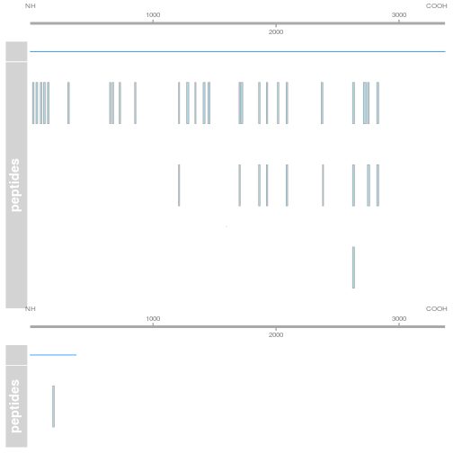

```r
plot(p[c(1,9)])
```

More details can be found in `?Proteins`. The object generated above is also directly available as `data(p)`.

```
## R Under development (unstable) (2014-04-10 r65396)
## Platform: x86_64-unknown-linux-gnu (64-bit)
##
## locale:
##  [1] LC_CTYPE=en_GB.UTF-8       LC_NUMERIC=C
##  [3] LC_TIME=en_GB.UTF-8        LC_COLLATE=en_GB.UTF-8
##  [5] LC_MONETARY=en_GB.UTF-8    LC_MESSAGES=en_GB.UTF-8
##  [7] LC_PAPER=en_GB.UTF-8       LC_NAME=C
##  [9] LC_ADDRESS=C               LC_TELEPHONE=C
## [11] LC_MEASUREMENT=en_GB.UTF-8 LC_IDENTIFICATION=C
##
## attached base packages:
## [1] grid      parallel  methods   stats     graphics  grDevices utils
## [8] datasets  base
##
```

[output cut: 43 more lines]